# WeRateDogs Twitter Data Analysis and Visualization

- Introduction
- Insights
- Conclusions and Recommendations

## Introduction

After the data gathering stage, data accessing stage, data cleaning stage and storing stage of the WeRateDog Twitter data,I continued to analysis and visualize the cleaned data. WeRateDogs is a Twitter account that rates people's dogs with a humorous comment about the dog. This analysis is based on a master WeRateDogs dataset that has been assessed and cleaned by me. I mainly used matplotlib module for my analysis, and it covered one-variable distribution.

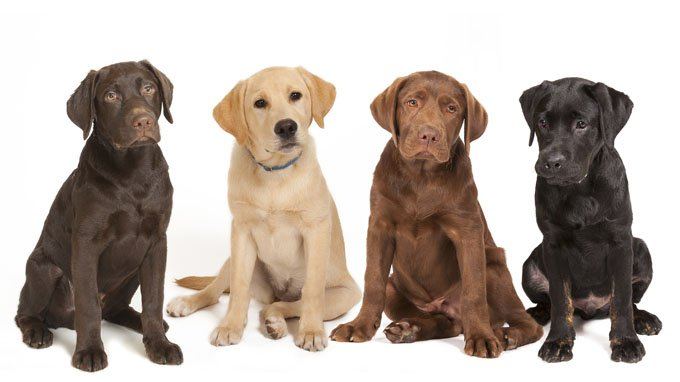

## Insights

I grouped all dogs in the data by name. It was gathered that most of the dogs are called by either the name, `A` which has the highest frequency of occurence, or by `Lucy`, which has the second highest frequency and then by the name, `Charlie`.

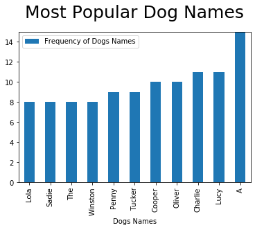

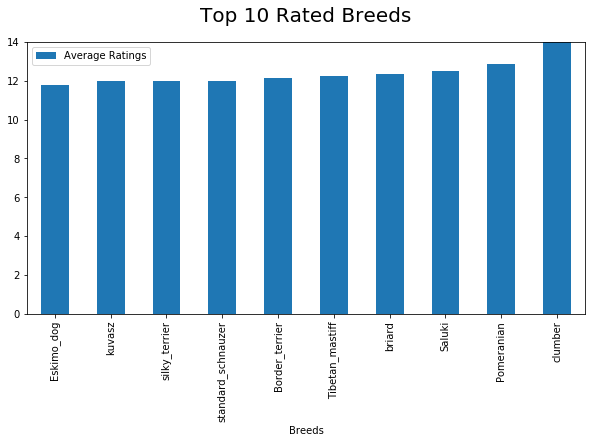

From the figure below, it could be seen that the least rated breed of dog from the WeRateDogs dataset is the `Japanese spaniel` with an average rating of `5`

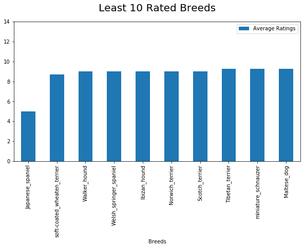

And lastly, the `Labrador retriever` was discovered to have the highest retweet count with a value of `79515`

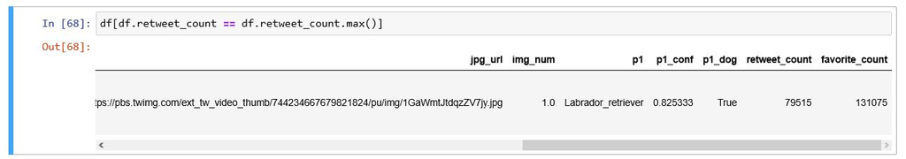

## Conclusion and Improvement

From the visualizations, we can clearly state that people rated the Labrador retriever by retweeting, though, reasons for this couldn't be arrived at with the provided data.

There are more to explore with this data. For example, the stage of the dogs clearly has a lot missing. I haven't got a chance to explore the prediction model provided, and also there are other data i haven't analysed.